# TravelTide

## Overview

This report offers a deep dive into our customers' travel behaviors and preferences. By analyzing our extensive data, we aim to uncover what drives our travelers and how to keep them engaged. Our approach segments customers into distinct groups or "traveler group," allowing for the customization of rewards and incentives that feel uniquely tailored to each group. This analysis distills vast data into clear, actionable metrics that shed light on travel patterns, service preferences, and responsiveness to promotions. The ultimate goal is to enhance customer loyalty and drive business success by keeping our travelers engaged with our services.

## Approach and Data Analysis

This section outlines how customer segmentation can be applied within TravelTide to create targeted rewards and incentives. By categorizing customers based on their behaviors and preferences, we can significantly improve customer satisfaction and loyalty.

Our objective is to leverage segmentation to deliver personalized perks that boost loyalty, engagement, and overall satisfaction. We aim to offer at least five specific perks:

## Reward Offerings:

- Exclusive Discounts
- 1 Night Free Hotel with Flight
- No Cancellation Fees
- Free Hotel Meal
- Free Checked Bag

## Data Processing and Metrics Creation

Starting with a dataset of 50,570 sessions, we distilled the information into 5,998 unique customers, using PostgreSQL to generate key metrics. This process was essential for simplifying the raw data into manageable and insightful variables.

Note: The SQL script file is in SQL folder.

## Key Metrics for Analysis

To determine the most suitable perks for each customer, we focused on the following aggregated metrics:

- Flight/Hotel/Both Preferences
- Average Nights
- Age Group
- Conversion Rate
- Cancellation Rate
- Total Sessions
- Total Trips Booked
- Engagement (Click Efficiency)
- User Activity Level
- Average Checked Bags
- Discount Responsiveness
- Proportions of Discounts (Flights/Hotels/Both)
- Average Offers Received
- Flight Hunter Index
- Hotel Hunter Index

Geo Distance is calculated in SQL.

## Packages need to be installed

- pip install scikit-learn
- pip install ipywidgets
- pip install -U kaleido

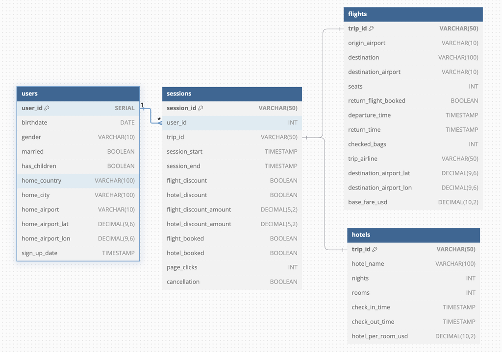

```python
import pandas as pd
import os
import numpy as np
from sklearn.preprocessing import StandardScaler
from sklearn.cluster import KMeans
from sklearn.decomposition import PCA
from datetime import datetime
import plotly.graph_objects as go
import plotly.express as px
import plotly.io as pio
from plotly.subplots import make_subplots
# custom functions
import Support.db_support as dbs
import Support.cus_support as cus
import Support.plot_support as plt
```

##### Git Image rendering issue

I am using Plotly on this project. Plotly interactive wont be supported in git. so, using using static image

```python
#pio.renderers.default = "png"
```

## Db Connection setup

```python
current_dir = os.getcwd()
```

```python
dbs.check_tables()
```

```
['hotels', 'users', 'flights', 'sessions']
```

```python
dbs.table_row_count()
```

```
hotels: 1918617 records
users: 1020926 records
flights: 1901038 records
sessions: 5408063 records
```

```python
#All_info_combined.sql
sql_file_path = os.path.join(current_dir, 'SQL', 'All_info_combined.sql')
#img_dir_path =  os.path.join(current_dir, 'Images')
csv_file_path = os.path.join(current_dir, 'csv', 'Final_output.csv')
```

```python
CombainedData = dbs.execute_sql_file(sql_file_path)
```

```python
CombainedData.head()
```

|  | user_id | birthdate | gender | married | has_children | home_country | home_city | age | age_group | latest_session | ... | discount_responsiveness | total_hotel_usd_spent | total_flight_usd_spent | total_usd_spent | total_nights | avg_nights | scaled_hotel_ads | ads_per_km | scaled_ads_per_km | hotel_hunter_index |
| --- | --- | --- | --- | --- | --- | --- | --- | --- | --- | --- | --- | --- | --- | --- | --- | --- | --- | --- | --- | --- | --- |
| 0 | 23557 | 1958-12-08 | F | True | False | usa | new york | 65.0 | 65+ | 2023-07-14 | ... | 0.083333 | 10939.5 | 706.9410 | 11646.4410 | 22.0 | 7.333333 | 0.146800 | 0.000007 | 0.002772 | 0.004282 |
| 1 | 94883 | 1972-03-16 | F | True | False | usa | kansas city | 52.0 | 45-54 | 2023-05-28 | ... | 0.027778 | 230.0 | 5354.8600 | 5584.8600 | 1.0 | 0.500000 | 0.004630 | 0.000002 | 0.000703 | 0.000058 |
| 2 | 101486 | 1972-12-07 | F | True | True | usa | tacoma | 51.0 | 45-54 | 2023-07-18 | ... | 0.000000 | 34770.0 | 2887.0515 | 37657.0515 | 38.0 | 7.600000 | 0.349940 | 0.000011 | 0.004808 | 0.000000 |
| 3 | 101961 | 1980-09-14 | F | True | False | usa | boston | 43.0 | 35-44 | 2023-06-22 | ... | 0.011905 | 23144.0 | 1924.2330 | 25068.2330 | 22.0 | 3.142857 | 0.133103 | 0.000019 | 0.007858 | 0.001109 |
| 4 | 106907 | 1978-11-17 | F | True | True | usa | miami | 45.0 | 45-54 | 2023-07-27 | ... | 0.017857 | 25574.8 | 14067.5700 | 39642.3700 | 34.0 | 8.500000 | 0.343194 | 0.000001 | 0.000589 | 0.004903 |

5 rows × 37 columns

```python
CombainedData.info()
```

```
<class 'pandas.core.frame.DataFrame'>
RangeIndex: 5998 entries, 0 to 5997
Data columns (total 37 columns):
 #   Column                      Non-Null Count  Dtype
---  ------                      --------------  -----
 0   user_id                     5998 non-null   int64
 1   birthdate                   5998 non-null   object
 2   gender                      5998 non-null   object
 3   married                     5998 non-null   bool
 4   has_children                5998 non-null   bool
 5   home_country                5998 non-null   object
 6   home_city                   5998 non-null   object
 7   age                         5998 non-null   float64
 8   age_group                   5998 non-null   object
 9   latest_session              5998 non-null   object
```

[output cut: 29 more lines]

```python
CombainedData[['user_id','total_trips','total_cancellations','total_cancellation_rate','flight_discount_proportion','hotel_discount_proportion','both_discount_proportion','discount_responsiveness']]
```

|  | user_id | total_trips | total_cancellations | total_cancellation_rate | flight_discount_proportion | hotel_discount_proportion | both_discount_proportion | discount_responsiveness |
| --- | --- | --- | --- | --- | --- | --- | --- | --- |
| 0 | 23557 | 5 | 1 | 0.20 | 0.083333 | 0.166667 | 0.0 | 0.083333 |
| 1 | 94883 | 3 | 0 | 0.00 | 0.083333 | 0.166667 | 0.0 | 0.027778 |
| 2 | 101486 | 5 | 1 | 0.20 | 0.307692 | 0.000000 | 0.0 | 0.000000 |
| 3 | 101961 | 7 | 0 | 0.00 | 0.250000 | 0.083333 | 0.0 | 0.011905 |
| 4 | 106907 | 4 | 1 | 0.25 | 0.071429 | 0.071429 | 0.0 | 0.017857 |
| ... | ... | ... | ... | ... | ... | ... | ... | ... |
| 5993 | 792549 | 4 | 0 | 0.00 | 0.125000 | 0.000000 | 0.0 | 0.093750 |
| 5994 | 796032 | 4 | 1 | 0.25 | 0.125000 | 0.000000 | 0.0 | 0.031250 |
| 5995 | 801660 | 3 | 0 | 0.00 | 0.375000 | 0.000000 | 0.0 | 0.000000 |
| 5996 | 811077 | 1 | 0 | 0.00 | 0.250000 | 0.125000 | 0.0 | 0.000000 |
| 5997 | 844489 | 0 | 0 | 0.00 | 0.125000 | 0.125000 | 0.0 | 0.000000 |

5998 rows × 8 columns

```python
CombainedData['flight_hunter_index'] = CombainedData['scaled_ads_per_km'] * CombainedData['flight_discount_proportion'] * CombainedData['average_flight_discount']
```

## User Demographics and Characteristics

### 1. Age Distribution

KPIs:

- Average Age: The mean age of all users.
- Median Age: The middle value when the ages are sorted.
- Age Group Distribution: The percentage of users in different age groups (e.g., 18-25, 26-35, etc.).

```python
# Calculate average and median age
average_age = CombainedData['age'].mean()
median_age = CombainedData['age'].median()

# Calculate age group distribution
age_group_distribution = CombainedData['age_group'].value_counts(normalize=True) * 100

# Display the results
print(f"Average Age: {average_age}")
print(f"Median Age: {median_age}")
print(f"Age Group Distribution:\n{age_group_distribution}")
```

```
Average Age: 41.97715905301767
Median Age: 42.0
Age Group Distribution:
age_group
35-44    33.711237
45-54    29.459820
25-34    14.888296
55-64     8.286095
18-24     8.136045
65+       4.318106
15-17     1.200400
Name: proportion, dtype: float64
```

### 2. Gender Distribution

KPIs:

- Gender Ratio: The percentage of male, female, and other gender categories.

```python
# Calculate gender distribution
gender_distribution = CombainedData['gender'].value_counts(normalize=True) * 100

# Display the results
print(f"Gender Distribution:\n{gender_distribution}")
```

```
Gender Distribution:
gender
F    88.229410
M    11.587196
O     0.183394
Name: proportion, dtype: float64
```

### 3. Marital Status

KPIs:

- Percentage Married: The percentage of users who are married.

```python
# Calculate marital status distribution
marital_status_distribution = CombainedData['married'].value_counts(normalize=True) * 100

# Display the results
print(f"Marital Status Distribution:\n{marital_status_distribution}")
```

```
Marital Status Distribution:
married
False    55.951984
True     44.048016
Name: proportion, dtype: float64
```

### 4. Parental Status

KPIs:

- Percentage with Children: The percentage of users who have children.

```python
# Calculate parental status distribution
parental_status_distribution = CombainedData['has_children'].value_counts(normalize=True) * 100

# Display the results
print(f"Parental Status Distribution:\n{parental_status_distribution}")
```

```
Parental Status Distribution:
has_children
False    67.355785
True     32.644215
Name: proportion, dtype: float64
```

### 5. Geographical Distribution (Home Country and City)

KPIs:

- Top Home Countries: The most common countries of origin among users.
- Top Home Cities: The most common cities of origin among users.

```python
# Calculate top home countries
top_home_countries = CombainedData['home_country'].value_counts().head(10)

# Calculate top home cities
top_home_cities = CombainedData['home_city'].value_counts().head(10)

# Display the results
print(f"Top Home Countries:\n{top_home_countries}")
print(f"Top Home Cities:\n{top_home_cities}")
```

```
Top Home Countries:
home_country
usa       4991
canada    1007
Name: count, dtype: int64
Top Home Cities:
home_city
new york       680
los angeles    325
toronto        225
chicago        195
houston        185
montreal       166
san antonio    132
phoenix        119
dallas         117
san diego      113
Name: count, dtype: int64
```

```python
CombainedData.describe(include='all')
```

|  | user_id | birthdate | gender | married | has_children | home_country | home_city | age | age_group | latest_session | ... | total_hotel_usd_spent | total_flight_usd_spent | total_usd_spent | total_nights | avg_nights | scaled_hotel_ads | ads_per_km | scaled_ads_per_km | hotel_hunter_index | flight_hunter_index |
| --- | --- | --- | --- | --- | --- | --- | --- | --- | --- | --- | --- | --- | --- | --- | --- | --- | --- | --- | --- | --- | --- |
| count | 5998.000000 | 5998 | 5998 | 5998 | 5998 | 5998 | 5998 | 5998.000000 | 5998 | 5998 | ... | 5998.000000 | 5998.000000 | 5998.000000 | 5435.000000 | 5998.000000 | 5998.000000 | 5998.000000 | 5998.000000 | 5998.000000 | 5998.000000 |
| unique | NaN | 4807 | 3 | 2 | 2 | 2 | 105 | NaN | 7 | 152 | ... | NaN | NaN | NaN | NaN | NaN | NaN | NaN | NaN | NaN | NaN |
| top | NaN | 1986-07-11 | F | False | False | usa | new york | NaN | 35-44 | 2023-07-20 | ... | NaN | NaN | NaN | NaN | NaN | NaN | NaN | NaN | NaN | NaN |
| freq | NaN | 5 | 5292 | 3356 | 4040 | 4991 | 680 | NaN | 2022 | 148 | ... | NaN | NaN | NaN | NaN | NaN | NaN | NaN | NaN | NaN | NaN |
| mean | 545440.695565 | NaN | NaN | NaN | NaN | NaN | NaN | 41.977159 | NaN | NaN | ... | 6537.746107 | 1154.159592 | 7691.905699 | 10.534499 | 3.509771 | 0.080592 | 0.000014 | 0.005887 | 0.000914 | 0.000235 |
| std | 64924.749760 | NaN | NaN | NaN | NaN | NaN | NaN | 12.046820 | NaN | NaN | ... | 8708.996625 | 1264.660755 | 9174.764532 | 8.300045 | 3.026964 | 0.086435 | 0.000046 | 0.019684 | 0.002028 | 0.001850 |
| min | 23557.000000 | NaN | NaN | NaN | NaN | NaN | NaN | 17.000000 | NaN | NaN | ... | 0.000000 | 0.000000 | 0.000000 | 0.000000 | 0.000000 | 0.000000 | 0.000000 | 0.000000 | 0.000000 | 0.000000 |
| 25% | 517152.000000 | NaN | NaN | NaN | NaN | NaN | NaN | 35.000000 | NaN | NaN | ... | 840.750000 | 378.791750 | 1599.531875 | 5.000000 | 1.666667 | 0.021176 | 0.000000 | 0.000000 | 0.000000 | 0.000000 |
| 50% | 540542.000000 | NaN | NaN | NaN | NaN | NaN | NaN | 42.000000 | NaN | NaN | ... | 3412.500000 | 896.470000 | 4701.727750 | 9.000000 | 3.000000 | 0.055659 | 0.000007 | 0.002935 | 0.000115 | 0.000034 |
| 75% | 574146.000000 | NaN | NaN | NaN | NaN | NaN | NaN | 49.000000 | NaN | NaN | ... | 8882.850000 | 1522.317000 | 10432.722500 | 14.000000 | 4.666667 | 0.110110 | 0.000017 | 0.007188 | 0.001080 | 0.000194 |
| max | 844489.000000 | NaN | NaN | NaN | NaN | NaN | NaN | 89.000000 | NaN | NaN | ... | 99052.400000 | 22376.087000 | 102754.420000 | 72.000000 | 30.000000 | 1.000000 | 0.002356 | 1.000000 | 0.074375 | 0.112500 |

11 rows × 38 columns

## Clustering our Dataset

```python
df = CombainedData.copy()

df['total_nights'] = df['total_nights'].fillna(0)

# Select relevant features for clustering
features = ['total_cancellation_rate', 'average_checked_bags', 'conversion_rate',
                     'prefers_flights', 'prefers_hotels', 'prefers_both',
                     'discount_responsiveness', 'flight_discount_proportion','average_flight_discount',
                     'hotel_discount_proportion', 'average_hotel_discount', 'both_discount_proportion',
                     'flight_hunter_index', 'hotel_hunter_index',
                     'total_hotel_usd_spent', 'total_flight_usd_spent','avg_nights' # , 'age'
                    ]


# Convert categorical features to numeric using one-hot encoding
df_encoded = pd.get_dummies(df[features], drop_first=True)

# Scale the features
scaler = StandardScaler()
df_scaled = scaler.fit_transform(df_encoded)

scaled_columns = [feature + "_scaled" for feature in features]
scaler = StandardScaler()
df[scaled_columns] = scaler.fit_transform(df[features])

# Apply K-Means clustering
kmeans = KMeans(n_clusters=5,n_init=10,  random_state=42)  # Adjust the number of clusters as needed
df['cluster'] = kmeans.fit_predict(df_scaled)

# Analyze the clusters
for cluster in range(5):
    print(f"Cluster {cluster}")
    print(df[df['cluster'] == cluster][scaled_columns].mean())
    #visual separator -----
    print('-'*50)
```

```
Cluster 0
total_cancellation_rate_scaled      -0.014038
average_checked_bags_scaled          0.133095
conversion_rate_scaled               0.159767
prefers_flights_scaled              -0.091999
prefers_hotels_scaled               -0.154848
prefers_both_scaled                  0.365541
discount_responsiveness_scaled       1.191980
flight_discount_proportion_scaled   -0.113195
average_flight_discount_scaled       0.380166
hotel_discount_proportion_scaled    -0.180802
average_hotel_discount_scaled        0.518412
both_discount_proportion_scaled      1.976928
flight_hunter_index_scaled           0.015036
hotel_hunter_index_scaled           -0.140144
total_hotel_usd_spent_scaled         0.009901
total_flight_usd_spent_scaled        0.024917
avg_nights_scaled                   -0.029955
dtype: float64
--------------------------------------------------
Cluster 1
total_cancellation_rate_scaled      -0.019060
average_checked_bags_scaled          0.126205
conversion_rate_scaled               0.124821
prefers_flights_scaled              -0.232393
prefers_hotels_scaled               -0.299406
prefers_both_scaled                  0.558823
discount_responsiveness_scaled      -0.563173
flight_discount_proportion_scaled    0.211208
average_flight_discount_scaled       0.063948
hotel_discount_proportion_scaled    -0.537672
average_hotel_discount_scaled       -0.711112
both_discount_proportion_scaled     -0.466282
flight_hunter_index_scaled           0.030221
hotel_hunter_index_scaled           -0.371702
total_hotel_usd_spent_scaled        -0.088470
total_flight_usd_spent_scaled        0.036459
avg_nights_scaled                   -0.138020
dtype: float64
--------------------------------------------------
```

[output cut: 45 more lines]

```
prefers_hotels_scaled                2.384757
prefers_both_scaled                 -1.481325
discount_responsiveness_scaled       0.795267
flight_discount_proportion_scaled    0.031909
average_flight_discount_scaled       0.005573
hotel_discount_proportion_scaled     0.126900
average_hotel_discount_scaled        0.059604
both_discount_proportion_scaled     -0.056808
flight_hunter_index_scaled           0.121618
hotel_hunter_index_scaled            0.170973
total_hotel_usd_spent_scaled        -0.135385
total_flight_usd_spent_scaled       -0.753411
avg_nights_scaled                    1.439711
dtype: float64
--------------------------------------------------
```

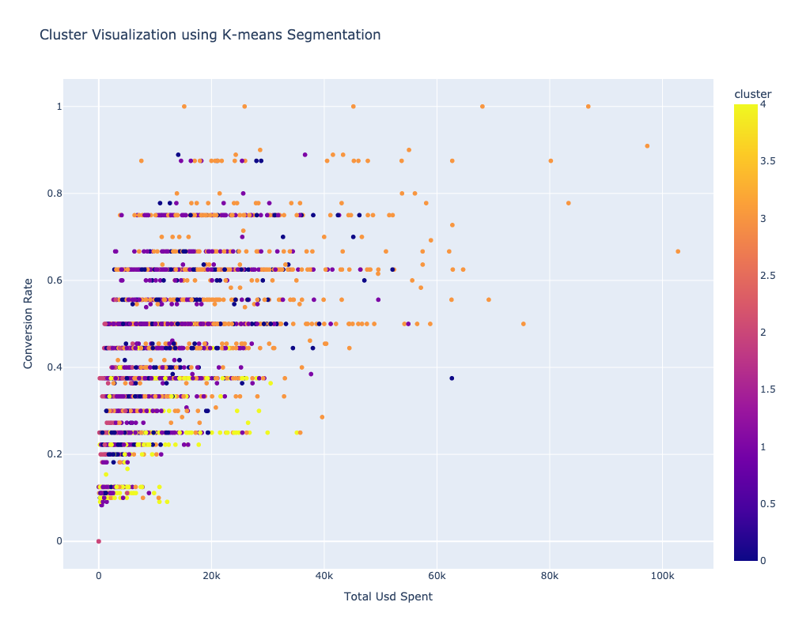

```python
plt.plot_clusters(df, 'total_usd_spent', 'conversion_rate')
```

### Optimizing Cluster Count with an Elbow Plot

Before moving forward with generated cluster. must determine number of cluster recomended for our dataset. so, I employed an elbow plot, which helps evaluate the significance of various cluster counts.

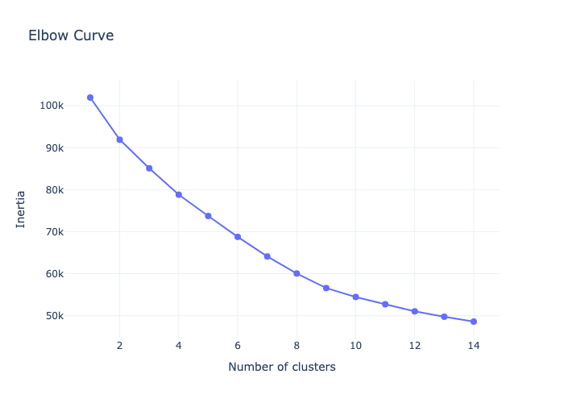

```python
# Elbow curve
plt.plot_elbow_curve(kmeans, df[scaled_columns], cluster_ranges=range(1, 15))
```

### Analyzing Plot:

Also our requirement from Elena stats 5, so I choose 5

### Correlation Matrix Heatmap

We need to verify that our metrics aren't strongly correlated, as high correlations between metrics can amplify the influence of the original variable in the k-means clustering algorithm, potentially leading to less than optimal results.

To mitigate this issue, I will utilize a correlation matrix paired with a heatmap. This visualization method enables us to examine the strength of relationships between different metrics. By identifying and analyzing any significant correlations, we can make informed decisions about which features to include, ensuring that the clustering process relies on relevant and independent attributes.

This step is essential to prevent problems that could arise from using redundant or overly similar metrics during clustering.

This completes the data transformation and aggregation tasks necessary for executing the clustering algorithm.

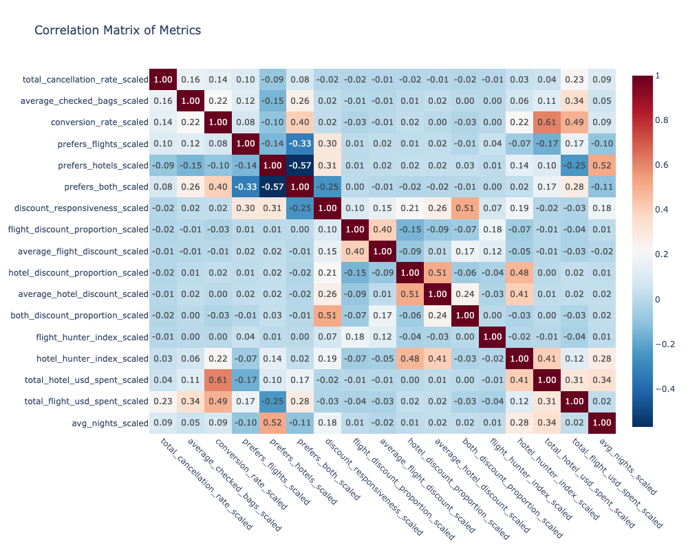

```
Highly correlated pairs:
Series([], dtype: float64)

 Now we can remove the highly correlated values, if any.

By removing highly correlated features, we can create a more efficient, interpretable, and reliable model. The goal is to retain only those features that provide unique and valuable information, leading to better performance and easier interpretation of the model.
```

```python
correlation_matrix = df[[  'total_cancellation_rate_scaled', 'average_checked_bags_scaled', 'conversion_rate_scaled',
                     'prefers_flights_scaled', 'prefers_hotels_scaled', 'prefers_both_scaled',
                     'discount_responsiveness_scaled', 'flight_discount_proportion_scaled','average_flight_discount_scaled',
                     'hotel_discount_proportion_scaled', 'average_hotel_discount_scaled', 'both_discount_proportion_scaled',
                     'flight_hunter_index_scaled', 'hotel_hunter_index_scaled',
                     'total_hotel_usd_spent_scaled', 'total_flight_usd_spent_scaled','avg_nights_scaled'
                          ]].corr()


# Plot the correlation heatmap
plt.plot_correlation_heatmap(correlation_matrix)


# Initialize set to hold pairs to be dropped (upper triangle of the matrix)
pairs_to_drop = set()
cols = correlation_matrix.columns
for i in range(0, correlation_matrix.shape[1]):
    for j in range(0, i+1):
        pairs_to_drop.add((cols[i], cols[j]))

# Unstack the correlation matrix and sort by absolute value
corr_abs_unstacked = correlation_matrix.abs().unstack()

# Drop pairs to get unique (i, j) correlations (avoid redundancy)
corr_abs_unstacked = corr_abs_unstacked.drop(labels=pairs_to_drop).sort_values(ascending=False)

# Extract highly correlated pairs (absolute value greater than 0.8)
high_corr = corr_abs_unstacked[corr_abs_unstacked > 0.8]


# Display pairs of highly correlated features
print("Highly correlated pairs: ")
print(high_corr)
# Note that features with high correlation may need to be treated carefully during modeling
print("\n Now we can remove the highly correlated values, if any.")
print("\nBy removing highly correlated features, we can create a more efficient, interpretable, and reliable model. The goal is to retain only those features that provide unique and valuable information, leading to better performance and easier interpretation of the model.")
```

### Cluster Labels

#### - **Cluster 0: "1 Night Free Hotel with Flight"**

**Reasoning:**

#### - **Cluster 1: "Exclusive Discounts"**

**Reasoning:**

#### - **Cluster 2: "No Cancellation Fee"**

**Reasoning:**

#### - **Cluster 3: "Free Checked Bag"**

**Reasoning:**

#### - **Cluster 4: "Free Hotel Meal"**

**Reasoning:**

In summary:

- **Cluster 0:** 1 Night Free Hotel with Flight
- **Cluster 1:** Exclusive Discounts
- **Cluster 2:** No Cancellation Fee
- **Cluster 3:** Free Checked Bag
- **Cluster 4:** Free Hotel Meal

```python
# Define the cluster labels
cluster_labels = {
    0: "1 Night Free Hotel with Flight",  # Cluster 0 matches with "1 Night Free Hotel with Flight"
    1: "Exclusive Discounts",            # Cluster 1 matches with "Exclusive Discounts"
    2: "No Cancellation Fee",            # Cluster 2 matches with "No Cancellation Fee"
    3: "Free Checked Bag",               # Cluster 3 matches with "Free Checked Bag"
    4: "Free Hotel Meal"                 # Cluster 4 matches with "Free Hotel Meal"
}

# Add the cluster labels to the DataFrame
df['cluster_label'] = df['cluster'].map(cluster_labels)

df.head()
```

|  | user_id | birthdate | gender | married | has_children | home_country | home_city | age | age_group | latest_session | ... | hotel_discount_proportion_scaled | average_hotel_discount_scaled | both_discount_proportion_scaled | flight_hunter_index_scaled | hotel_hunter_index_scaled | total_hotel_usd_spent_scaled | total_flight_usd_spent_scaled | avg_nights_scaled | cluster | cluster_label |
| --- | --- | --- | --- | --- | --- | --- | --- | --- | --- | --- | --- | --- | --- | --- | --- | --- | --- | --- | --- | --- | --- |
| 0 | 23557 | 1958-12-08 | F | True | False | usa | new york | 65.0 | 65+ | 2023-07-14 | ... | 0.623531 | 1.448769 | -0.466282 | -0.108578 | 1.660814 | 0.505468 | -0.353657 | 1.263272 | 3 | Free Checked Bag |
| 1 | 94883 | 1972-03-16 | F | True | False | usa | kansas city | 52.0 | 45-54 | 2023-05-28 | ... | 0.623531 | -0.009523 | -0.466282 | -0.124145 | -0.422200 | -0.724340 | 3.321879 | -0.994403 | 3 | Free Checked Bag |
| 2 | 101486 | 1972-12-07 | F | True | True | usa | tacoma | 51.0 | 45-54 | 2023-07-18 | ... | -0.958083 | -1.103241 | -0.466282 | -0.067317 | -0.450740 | 3.242005 | 1.370357 | 1.351377 | 1 | Exclusive Discounts |
| 3 | 101961 | 1980-09-14 | F | True | False | usa | boston | 43.0 | 35-44 | 2023-06-22 | ... | -0.167276 | 0.355050 | -0.466282 | 0.014316 | 0.096274 | 1.906952 | 0.608968 | -0.121225 | 3 | Free Checked Bag |
| 4 | 106907 | 1978-11-17 | F | True | True | usa | miami | 45.0 | 45-54 | 2023-07-27 | ... | -0.280248 | 1.813341 | -0.466282 | -0.123900 | 1.967126 | 2.186089 | 10.211819 | 1.648729 | 3 | Free Checked Bag |

5 rows × 57 columns

```python
cluster_counts = df['cluster_label'].value_counts()

print(cluster_counts)
```

```
cluster_label
Exclusive Discounts               2205
Free Checked Bag                  1414
1 Night Free Hotel with Flight     899
No Cancellation Fee                880
Free Hotel Meal                    600
Name: count, dtype: int64
```

#### Cluster distribution

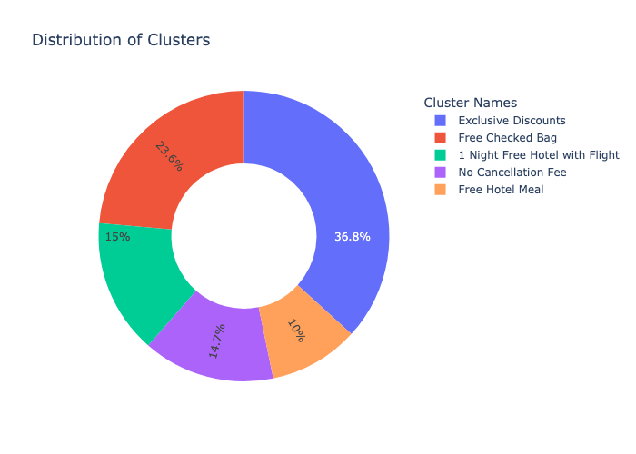

```python
plt.plot_cluster_pie_chart(df)
```

### Cluster Heatmap

With our dataset now ready with our clustering, we can move forward with analyzing and visualizing the clusters I've identified.

I generated a heatmap to illustrate these clusters, labeling them according to their distinct "Group" behaviors. The labeling is based on the metrics associated with each cluster, as shown in the heatmap below.

This visualization is crucial as it provides the foundation for assigning specific perks to each "Group," enabling us to customize our offerings more effectively.

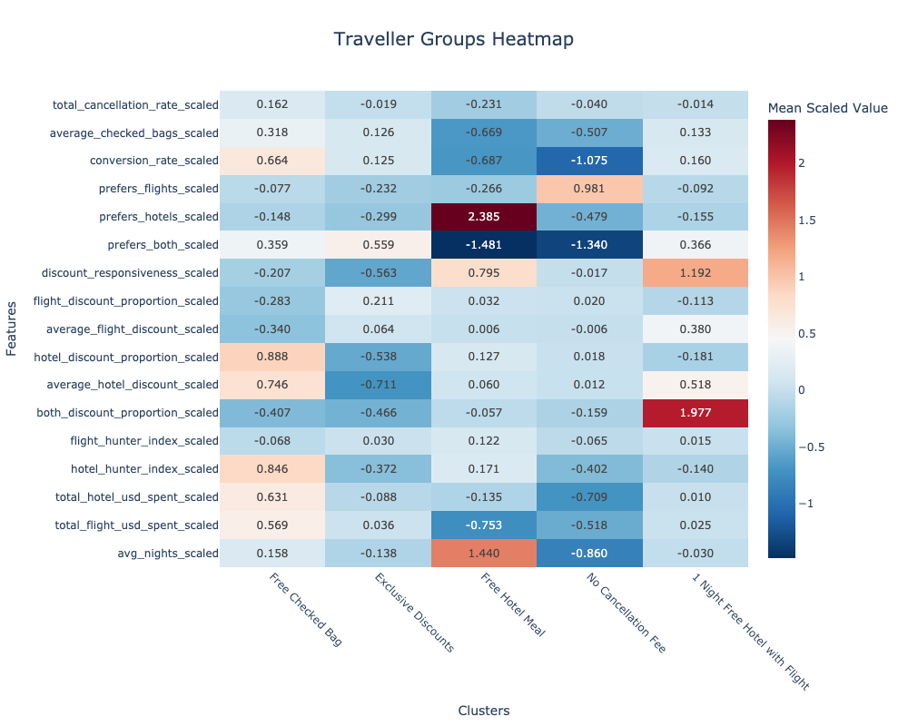

```python
plt.plot_cluster_heatmap(df, 'cluster', scaled_columns, 'cluster_label')
```

### Plotting Married status per Perk

The following code generates a stacked bar chart that shows the distribution of Married status for each perk using percentages.

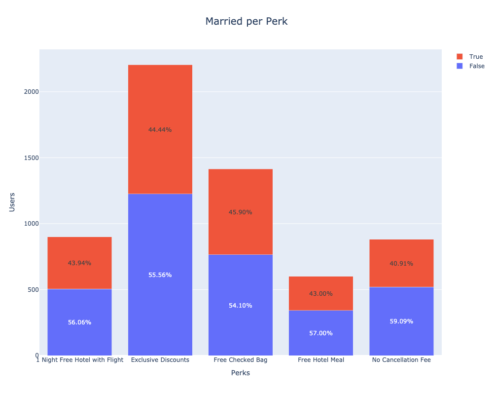

```python
plt.plot_stacked_bar_with_percentages(df,'cluster_label','married', 'Perks','Users',  'Married per Perk')
```

As we see from the above chart. Unmarried users are dominent in our perk, as it distributed widely. cause they are the dominent in our users.

#### Top 'N' City Preference by perk

Following chart is to identify the Top N (5) cities our assigned Perk.

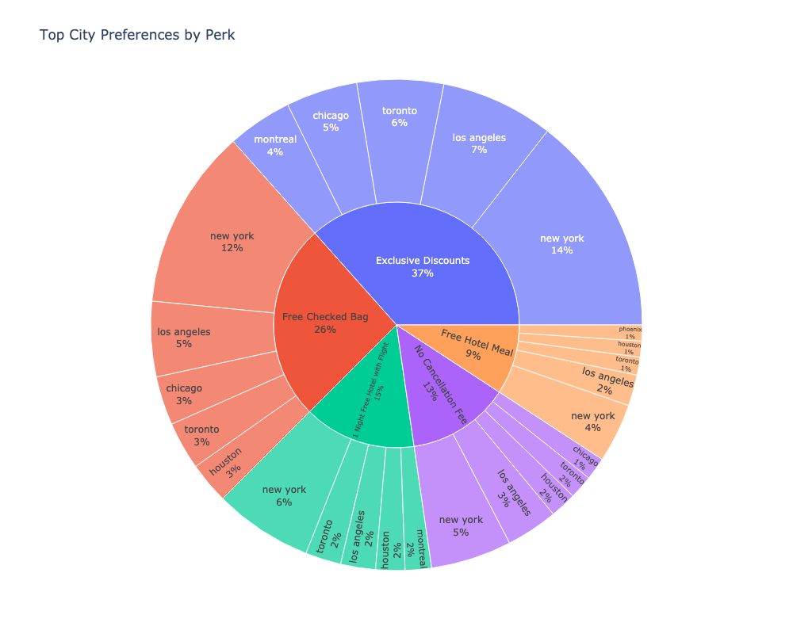

```python
plt.plot_sunburst_chart(df, category_column='home_city', top_n=5,  chart_title='Top City Preferences by Perk')
```

As of above chart 'New york' is more dominent in our perk

#### Age Group by Perk

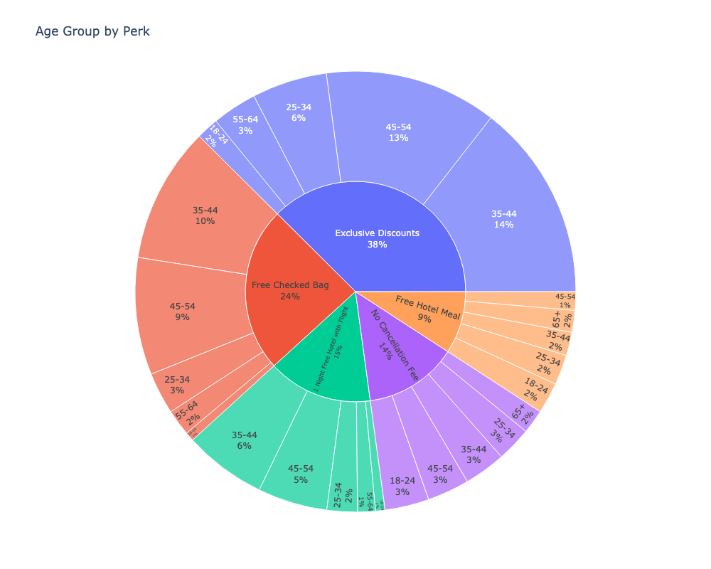

```python
plt.plot_sunburst_chart(df, category_column='age_group', chart_title='Age Group by Perk')
```

```python
df.columns
```

```
Index(['user_id', 'birthdate', 'gender', 'married', 'has_children',
       'home_country', 'home_city', 'age', 'age_group', 'latest_session',
       'total_trips', 'total_cancellations', 'total_sessions',
       'total_cancellation_rate', 'average_checked_bags', 'prefers_flights',
       'prefers_hotels', 'prefers_both', 'conversion_rate', 'average_clicks',
       'total_clicks', 'click_efficiency', 'average_hotel_discount',
       'average_flight_discount', 'flight_discount_proportion',
       'hotel_discount_proportion', 'both_discount_proportion',
       'discount_responsiveness', 'total_hotel_usd_spent',
       'total_flight_usd_spent', 'total_usd_spent', 'total_nights',
       'avg_nights', 'scaled_hotel_ads', 'ads_per_km', 'scaled_ads_per_km',
       'hotel_hunter_index', 'flight_hunter_index',
       'total_cancellation_rate_scaled', 'average_checked_bags_scaled',
       'conversion_rate_scaled', 'prefers_flights_scaled',
       'prefers_hotels_scaled', 'prefers_both_scaled',
       'discount_responsiveness_scaled', 'flight_discount_proportion_scaled',
       'average_flight_discount_scaled', 'hotel_discount_proportion_scaled',
       'average_hotel_discount_scaled', 'both_discount_proportion_scaled',
       'flight_hunter_index_scaled', 'hotel_hunter_index_scaled',
       'total_hotel_usd_spent_scaled', 'total_flight_usd_spent_scaled',
       'avg_nights_scaled', 'cluster', 'cluster_label'],
      dtype='object')
```

### Analysis & Insights

In this section, I will explore the key insights derived from the customer segmentation study. I'll describe how customers were categorized into different "Groups" based on factors such as travel preferences, age, and the likelihood of completing a booking after visiting our platform. We will also look at how these groupings enable us to offer more tailored services and promotions.

*Note: The visual data provided below has been clustered using the k-means algorithm and serves as a visual aid to better understand the relevance of the selected metrics.*

#### User Behaviour b/w Total Booking/Cancellation/Success rate

**Total Bookings**  
**Metric**: `total_trips`.

**Booking Cancellation Rate**  
**Metric**: `total_cancellation_rate`.

**Booking Success Rate**  
**Metric**: `conversion_rate`.

Please refer to the graphic below for a visualization of user behavior across all “User Groups.”

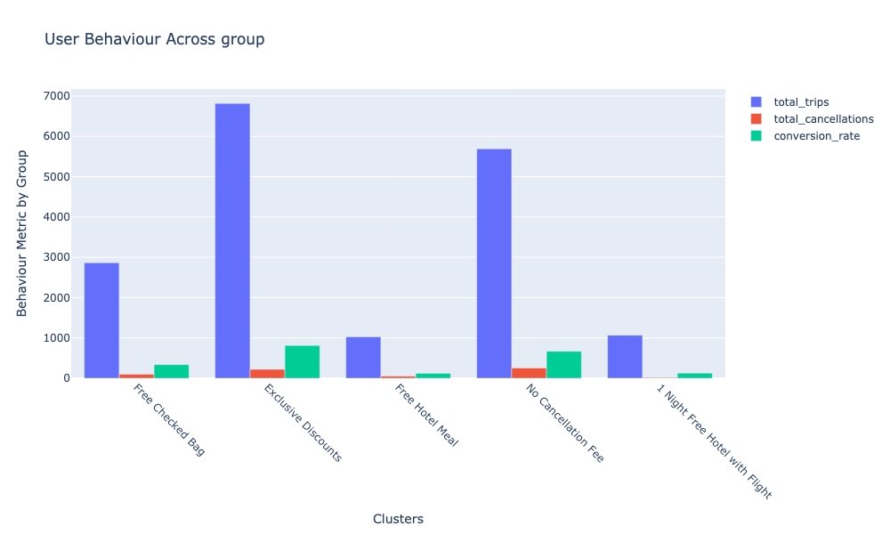

```python
plt.plot_user_behavior(
    df,
    x_column='cluster',
    y_columns=['total_trips', 'total_cancellations', 'conversion_rate'],
    x_labels =df['cluster_label'].unique().tolist(),
    y_axis_label='Behaviour Metric by Group',
    chart_title='User Behaviour Across group'
)
```

#### **Travel Preference Across Groups**

**Metrics:** `prefers_hotels`, `prefers_flights`, `prefers_both`

**Description:** This chart displays travel preferences across different clusters, highlighting how customers in each group favor hotels (`prefers_hotels`), flights (`prefers_flights`), or both (`prefers_both`). By analyzing these behavior metrics, we can better understand the preferences of each cluster and tailor our marketing strategies accordingly. This visualization helps us identify which travel options are most popular within each group and optimize our offerings to meet their needs.

Please refer to the chart below for a detailed breakdown of travel preferences across all clusters.

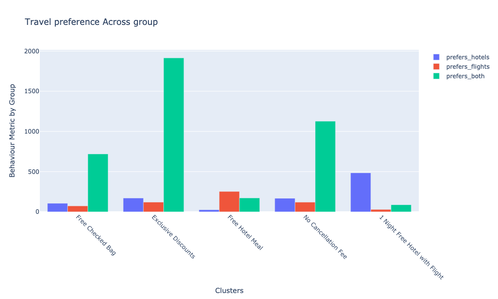

```python
plt.plot_user_behavior(
    df,
    x_column='cluster',
    y_columns=['prefers_hotels', 'prefers_flights', 'prefers_both'],
    x_labels =df['cluster_label'].unique().tolist(),
    y_axis_label='Behaviour Metric by Group',
    chart_title='Travel preference Across group'
)
```

#### Discount Preference.

**Discount Preferences (Flights, Hotels, or Both)**  
**Metric(s):** `discount_responsiveness`, `average_flight_discount`, `average_hotel_discount`.

**Description:** Analyzing customer preferences for discounts on flights, hotels, or both allows us to understand their booking tendencies. By evaluating metrics such as discount_responsiveness_flights, discount_responsiveness_hotels, and discount_responsiveness_combined, we can tailor our promotional offers to match their specific interests. This targeted approach enhances our ability to engage customers with relevant deals.

Please refer to the graphic below for a visualization of user preferences across all "Traveler Groups."

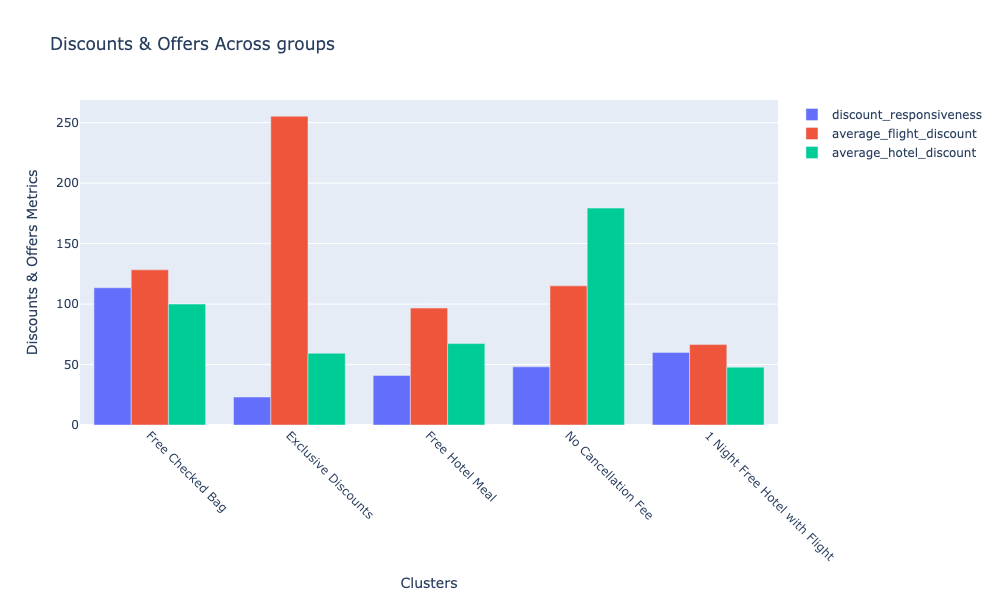

```python
plt.plot_user_behavior(
    df,
    x_column='cluster',
    y_columns=['discount_responsiveness', 'average_flight_discount', 'average_hotel_discount'],
    x_labels =df['cluster_label'].unique().tolist(),
    y_axis_label='Discounts & Offers Metrics',
    chart_title='Discounts & Offers Across groups'
)
```

#### **Financial Overview Across Groups**

**Metrics:** `total_hotel_usd_spent`, `total_flight_usd_spent`, `total_usd_spent`

**Description:** This chart provides a financial overview of customer behavior across different clusters. It illustrates the total spending on hotels (`total_hotel_usd_spent`), flights (`total_flight_usd_spent`), and combined expenditures (`total_usd_spent`). By examining these metrics, we gain insights into the financial impact of each cluster and their overall spending patterns. This information helps us understand how different groups allocate their budgets and enables more informed decision-making for targeting and strategy.

Please refer to the chart below for a detailed comparison of financial metrics across all clusters.

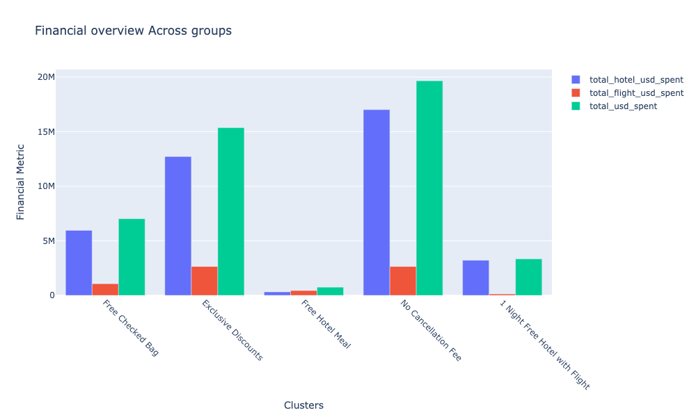

```python
plt.plot_user_behavior(
    df,
    x_column='cluster',
    y_columns=['total_hotel_usd_spent', 'total_flight_usd_spent', 'total_usd_spent'],
    x_labels =df['cluster_label'].unique().tolist(),
    y_axis_label='Financial Metric',
    chart_title='Financial overview Across groups'
)
```

#### Save the final dataframe as csv

```python
df.to_csv(csv_file_path, index=False)
```

### Recommendations for the TravelTide Project

Based on the analysis of customer travel behavior, the following recommendations are provided to enhance customer engagement, loyalty, and overall business success:

#### 1. Optimize Customer Segmentation for Targeted Marketing:

- **Refine Clustering Approach**: Use techniques such as the Elbow Method or Silhouette Score to determine the optimal number of clusters for customer segmentation. This will ensure that each customer group is distinct and meaningful, leading to more effective targeting.
- **Experiment with Different Clustering Algorithms**: While KMeans is a good starting point, consider experimenting with other clustering methods, like Hierarchical Clustering or DBSCAN, to capture non-linear relationships or to better handle noise in the data.
- **Incorporate More Behavioral Data**: Enhance segmentation by integrating more dynamic behavioral data, such as recent booking activity, browsing patterns, or responsiveness to past marketing campaigns. This will help in creating more personalized offers.

#### 2. Enhance Data Quality and Feature Engineering:

- **Address Missing Data**: Ensure that all missing values are handled appropriately. Use imputation techniques (mean, median, mode, or advanced methods like KNN imputation) to fill missing data where possible, or exclude unreliable data points.
- **Feature Normalization**: Apply normalization or standardization to all numerical features before clustering to ensure that features are on the same scale, preventing bias toward features with larger ranges.
- **Create Derived Features**: Develop new features that may provide more insights into customer behavior. For example, consider creating features like "recency of last trip," "frequency of trips," or "average lead time for bookings."

#### 3. Personalize Marketing Strategies:

- **Develop Tailored Offers for Each Segment**: Based on the customer segmentation, create customized offers that align with each group’s preferences. For example, frequent business travelers might value free checked bags or flexible cancellation policies, while leisure travelers may prefer exclusive discounts or free hotel nights.
- **Use Dynamic Content Personalization**: Implement dynamic content in marketing communications (e.g., emails, push notifications) that adapts based on the customer’s segment. Highlight benefits most relevant to their behavior and preferences, such as specific discounts or rewards that align with their past booking patterns.

#### 4. Leverage Predictive Analytics for Customer Retention:

- **Predict Churn Risk**: Develop a model to predict the likelihood of customer churn based on past behavior, such as declining booking frequency or increasing cancellation rates. Proactively target these customers with retention-focused offers (e.g., exclusive discounts, loyalty rewards).
- **Forecast Future Demand**: Use time-series forecasting techniques to predict demand for certain destinations, hotels, or flights. This can help in better managing inventory, pricing, and targeted marketing campaigns.

#### 5. Improve Engagement Through Enhanced User Experience:

- **Optimize the Booking Funnel**: Analyze conversion rates at each step of the booking process to identify any friction points. Use A/B testing to optimize key elements of the user journey, such as page layouts, call-to-action buttons, or payment options.
- **Utilize Gamification**: Introduce gamification elements (e.g., points, badges, leaderboards) to increase engagement. Reward customers for specific actions, such as booking during off-peak periods or sharing their travel experiences.

#### 6. Expand Reward Offerings:

- **Diversify Incentives**: Beyond the current rewards (exclusive discounts, free hotel nights, etc.), consider introducing new incentives based on customer feedback, such as loyalty points, concierge services, or upgrades.
- **Create Tiered Loyalty Programs**: Develop a tiered loyalty program that offers progressively better rewards as customers increase their engagement. This can encourage repeat bookings and higher spending levels.

#### 7. Validate and Iterate on Findings:

- **Conduct A/B Tests**: Implement A/B testing to validate the effectiveness of different marketing strategies and offers. Use metrics like click-through rates, conversion rates, and customer satisfaction scores to gauge success.
- **Iteratively Improve Segmentation**: Regularly update customer segmentation models to reflect changes in customer behavior or market conditions. Continuously collect data and refine models to ensure they remain accurate and relevant.

By implementing these recommendations, TravelTide can achieve a more granular understanding of its customer base and deliver highly personalized experiences that drive engagement, loyalty, and revenue growth. The focus should be on continuously refining data-driven customer segmentation, enhancing marketing strategies, and leveraging predictive analytics to anticipate customer needs and preferences. Ultimately, these actions will position TravelTide to stay competitive in a dynamic travel market and foster long-term customer relationships.